# 5.1 Geometric Operations

`geopandas` makes available all the tools for geometric manipulations in the `shapely` library.

Here is a list of supported geometric operations in `geopandas`, most of them can be used on aGeoDataFrame or GeoSeries.

- GeoSeries.buffer(distance): Create a buffer to the shape (point, line, polygon)
- GeoSeries.centroid: Calculate the geometric centroid of a shape
- GeoSeries.area: Calculate the area of a shape
- GeoSeries.length: Calculate the length a shape

```python
!pip install geopandas
import geopandas as gpd
import matplotlib.pyplot as plt
%matplotlib inline
```

Let's play around with those methods using the US lower 48 states example.

```python
states = gpd.read_file("../data/US_lower_48/US_lower_48.shp")
```

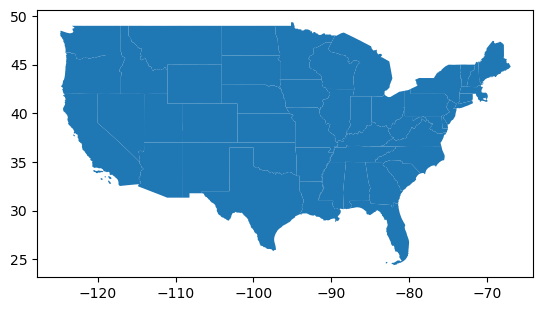

```python
states.plot()
```

First of all, let's calculate the centroid of each state.

```python
states.centroid
```

```
0      POINT (-80.61371 38.64257)
1      POINT (-82.46642 28.47706)
2       POINT (-89.14864 40.1242)
3      POINT (-94.19834 46.34927)
4      POINT (-76.68718 38.94649)
5     POINT (-114.65941 44.38906)
6      POINT (-71.57124 43.68024)
7      POINT (-79.13089 35.52604)
8      POINT (-72.66263 44.07525)
9      POINT (-72.73826 41.57516)
10     POINT (-75.45249 38.99497)
11     POINT (-106.10844 34.4213)
12    POINT (-119.66385 37.21531)
13     POINT (-74.65561 40.11018)
14     POINT (-89.73293 44.63994)
```

[output cut: 34 more lines]

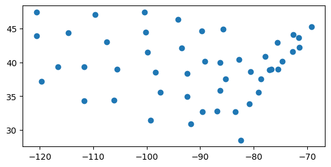

```python
states.centroid.plot()
```

Overlay state centroids with the state polygons.

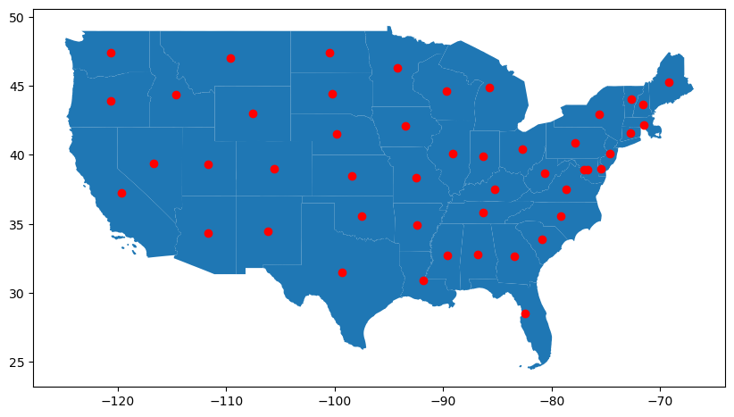

```python
fig, ax = plt.subplots(1, 1,figsize=(10,8))
states.plot(ax=ax)
states.centroid.plot(ax=ax,color="red")
```

Then, let's create a buffer to each of the centroid. Before we do that, one important step is to check the projection. If you remember, this one is not projected.

```python
states.crs
```

```
<Geographic 2D CRS: EPSG:4269>
Name: NAD83
Axis Info [ellipsoidal]:
- Lat[north]: Geodetic latitude (degree)
- Lon[east]: Geodetic longitude (degree)
Area of Use:
- name: North America - onshore and offshore: Canada - Alberta; British Columbia; Manitoba; New Brunswick; Newfoundland and Labrador; Northwest Territories; Nova Scotia; Nunavut; Ontario; Prince Edward Island; Quebec; Saskatchewan; Yukon. Puerto Rico. United States (USA) - Alabama; Alaska; Arizona; …
- bounds: (167.65, 14.92, -40.73, 86.45)
Datum: North American Datum 1983
- Ellipsoid: GRS 1980
- Prime Meridian: Greenwich
```

```python
states_projected = states.to_crs(epsg='3857')
```

Project it to mercator, so the the buffering distance will be in the unit of meters rather than arc-degree.

```python
buffers = states_projected.centroid.buffer(distance=200000) #This is a 200 kilometer buffer
```

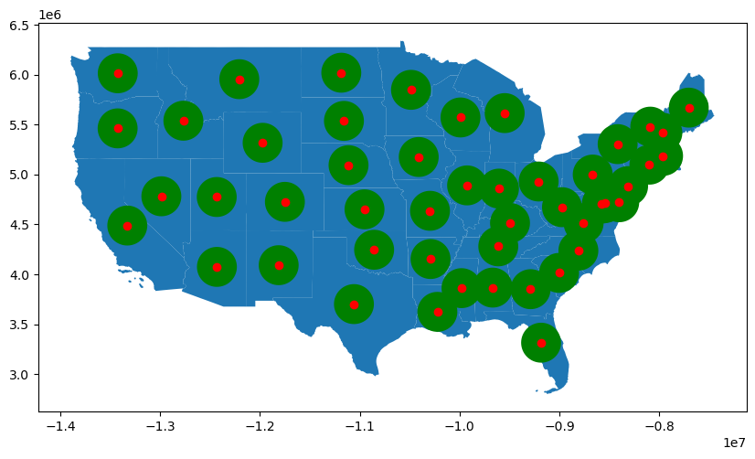

```python
fig, ax = plt.subplots(1, 1,figsize=(10,8))
states_projected.plot(ax=ax)
buffers.plot(ax=ax,color="green")
states_projected.centroid.plot(ax=ax,color="red")
```

Then let's calcuate the area and length of each state, and create two new columns in the states GeoDataFrame.

```python
states_projected['state_area'] = states_projected.area
states_projected['state_length'] = states_projected.length
```

Let's find out which state has the largest area? Have a guess before running the command?

```python
states_projected.sort_values('state_area', ascending=False)[['NAME','state_area']]
```

|  | NAME | state_area |
| --- | --- | --- |
| 24 | Texas | 9.607227e+11 |
| 39 | Montana | 8.201831e+11 |
| 12 | California | 6.718940e+11 |
| 35 | Michigan | 4.997446e+11 |
| 15 | Oregon | 4.919326e+11 |
| 34 | Nevada | 4.802968e+11 |
| 29 | Wyoming | 4.741973e+11 |
| 3 | Minnesota | 4.732057e+11 |
| 11 | New Mexico | 4.644023e+11 |
| 25 | Colorado | 4.473108e+11 |
| 47 | Arizona | 4.340643e+11 |
| 5 | Idaho | 4.246751e+11 |
| 18 | Washington | 4.032408e+11 |
| 30 | North Dakota | 4.003531e+11 |
| 42 | South Dakota | 3.919818e+11 |
| 22 | Utah | 3.682859e+11 |
| 16 | Nebraska | 3.578636e+11 |
| 40 | Kansas | 3.484440e+11 |
| 14 | Wisconsin | 3.353652e+11 |
| 38 | Missouri | 2.943632e+11 |
| 27 | Oklahoma | 2.744188e+11 |
| 46 | Iowa | 2.648092e+11 |
| 33 | New York | 2.637690e+11 |
| 2 | Illinois | 2.570904e+11 |
| 1 | Florida | 2.215000e+11 |
| 20 | Georgia | 2.177853e+11 |
| 7 | North Carolina | 2.109424e+11 |
| 17 | Pennsylvania | 2.090129e+11 |
| 36 | Arkansas | 2.053260e+11 |
| 23 | Ohio | 2.005834e+11 |
| 21 | Alabama | 1.926308e+11 |
| 32 | Maine | 1.851445e+11 |
| 19 | Louisiana | 1.849586e+11 |
| 37 | Mississippi | 1.778440e+11 |
| 44 | Virginia | 1.764152e+11 |
| 31 | Kentucky | 1.667121e+11 |
| 28 | Tennessee | 1.664790e+11 |
| 41 | Indiana | 1.606546e+11 |
| 26 | South Carolina | 1.206649e+11 |
| 0 | West Virginia | 1.030459e+11 |
| 4 | Maryland | 5.320401e+10 |
| 43 | Massachusetts | 4.978455e+10 |
| 8 | Vermont | 4.827445e+10 |
| 6 | New Hampshire | 4.632641e+10 |
| 13 | New Jersey | 3.867718e+10 |
| 9 | Connecticut | 2.567823e+10 |
| 10 | Delaware | 1.068708e+10 |
| 45 | District of Columbia | 2.927452e+08 |

Let's find out which state has the largest length (circumference)? Have another guess?

```python
states_projected.sort_values('state_length', ascending=False)[['NAME','state_length']]
```

|  | NAME | state_length |
| --- | --- | --- |
| 24 | Texas | 6.845591e+06 |
| 12 | California | 5.257989e+06 |
| 39 | Montana | 4.615753e+06 |
| 3 | Minnesota | 4.510422e+06 |
| 5 | Idaho | 4.197446e+06 |
| 35 | Michigan | 3.795814e+06 |
| 1 | Florida | 3.734787e+06 |
| 27 | Oklahoma | 3.307801e+06 |
| 15 | Oregon | 3.282428e+06 |
| 33 | New York | 3.212606e+06 |
| 30 | North Dakota | 3.125605e+06 |
| 19 | Louisiana | 3.078644e+06 |
| 34 | Nevada | 3.054836e+06 |
| 38 | Missouri | 3.050107e+06 |
| 14 | Wisconsin | 3.030128e+06 |
| 42 | South Dakota | 2.963038e+06 |
| 44 | Virginia | 2.949640e+06 |
| 18 | Washington | 2.926237e+06 |
| 16 | Nebraska | 2.922198e+06 |
| 47 | Arizona | 2.907360e+06 |
| 11 | New Mexico | 2.900303e+06 |
| 2 | Illinois | 2.861004e+06 |
| 37 | Mississippi | 2.855253e+06 |
| 29 | Wyoming | 2.777134e+06 |
| 31 | Kentucky | 2.753449e+06 |
| 25 | Colorado | 2.708265e+06 |
| 7 | North Carolina | 2.668713e+06 |
| 36 | Arkansas | 2.656504e+06 |
| 28 | Tennessee | 2.621413e+06 |
| 0 | West Virginia | 2.614070e+06 |
| 40 | Kansas | 2.570737e+06 |
| 22 | Utah | 2.557182e+06 |
| 32 | Maine | 2.553982e+06 |
| 20 | Georgia | 2.528321e+06 |
| 46 | Iowa | 2.527129e+06 |
| 41 | Indiana | 2.212954e+06 |
| 17 | Pennsylvania | 2.174488e+06 |
| 23 | Ohio | 2.127152e+06 |
| 21 | Alabama | 2.125037e+06 |
| 26 | South Carolina | 1.863644e+06 |
| 4 | Maryland | 1.835189e+06 |
| 43 | Massachusetts | 1.478876e+06 |
| 6 | New Hampshire | 1.360486e+06 |
| 8 | Vermont | 1.281076e+06 |
| 13 | New Jersey | 1.095415e+06 |
| 9 | Connecticut | 7.073967e+05 |
| 10 | Delaware | 5.417986e+05 |
| 45 | District of Columbia | 8.630065e+04 |